# Aiyagari Model

Lecturer: Bo Li

libo.econ@pku.edu.cn

School of Economics, Peking University

TA: Chen Gao

chengao0716@gmail.com

National School of Development, Peking University

2026-04-07

# Model Description

## A Standard Savings Problem

The economy is populated by a large number of ex-ante identical but ex-post heterogeneous households.

Households trade in a single security to insure against risks.

There is no aggregate uncertainty, implying that the aggregate variables will be constant in the stationary equilibrium.

Individual income at period $t$, denoted by $s_t$, follows an $m$-state Markov chain with transition matrix $\pi$.

We have that:

- $s_t \in \{s_1, s_2, \ldots, s_m\}$
- $\pi_{ij} = \Pr(s_{t+1} = s_j \mid s_t = s_i)$ for $i=1,\ldots,m$ and $j=1,\ldots,m$

## A Standard Savings Problem

If the realization of the process at period $t$ is $s_t$, a household receives labor income equal to $w s_t$, where $w$ is the wage rate.

If the asset holdings of the household at the beginning of the period are equal to $a_t$, she receives a gross return of $(1 + r)a_t$.

For given $(w, r)$ and $(a_0, s_0)$, the household solves:

$$\begin{aligned}
\max_{\{c_t, a_{t+1}\}_{t=0}^{\infty}} \quad & \mathbb{E}_0 \left[ \sum_{t=0}^{\infty} \beta^t u(c_t) \right] \\
\text{s.t.} \quad & c_t + a_{t+1} = (1 + r)a_t + w s_t \\
& a_{t+1} \in A
\end{aligned}$$

## Assumptions of the Standard Savings Problem

We assume that $\beta \in (0,1)$ and $u(c)$ satisfies $\lim_{c \to 0} u'(c) = \infty$. This last assumption ensures that $c > 0$. In addition, $u(c)$ is strictly increasing, strictly concave, and twice continuously differentiable.

An important assumption is $\beta(1+r) < 1$. This prevents assets from growing to infinity.

Regarding the factor prices $(w, r)$, we distinguish between two cases:

- **Pure exchange economy:** Each household can borrow or lend in a zero net supply asset at a constant $r$, while the wage $w$ is also constant. This is the set-up studied by Huggett (1993).
- **Production economy:** Both factor prices are determined by the firm in equilibrium. This is the set-up studied by Aiyagari (1994).

## Dynamic Programming Problem

If we discretize the state space, the problem of the household can be solved using standard numerical dynamic programming techniques.

- The individual state is given by the pair $(a_t, s_t)$, where $s_t$ is already discrete.
- We assume that the asset holdings can only take a finite number of values, i.e., $a_t \in \{a_1, a_2, \ldots, a_n\}$, incorporating upper and lower limits on how much can be borrowed.

The dynamic programming problem of the household is then given by:

$$v(a, s) = \max_{a' \in A} \left\{ u\big[(1 + r)a + ws - a'\big] + \beta \sum_j \pi_{ij} v(a', s_j) \right\} \\
\text{subject to} \quad c + a' = (1 + r)a + ws$$

## Solution and Stationary Distribution

Given $(w, r)$, the solution consists of the optimal value and policy functions $v(a, s)$, $a' = g_a(a, s)$ and $c = g_c(a, s)$.  
The policy functions have to satisfy market clearing when aggregated over households.

To aggregate, however, we need the asset-employment distribution, making this type of model more complicated than the standard representative household environment.

We use the fact that a **stationary employment-wealth distribution** can be obtained by defining a Markov process for the distribution and by calculating the stationary distribution of this Markov chain.

## Solution and Stationary Distribution

We approximate the process for $(a, s)$ with a Markov chain, and define a stationary probability vector $\lambda(a_n, s_m)$, where

$$\lambda(a_n, s_m) = \Pr(a_t = a_n, s_t = s_m)$$

$\lambda(a, s)$ represents the fraction of time that a household with state $(a, s)$ spends in that state.

Alternatively, $\lambda(a, s)$ can be interpreted as the fraction of households with asset holdings $a$ and labor endowment $s$. There is an equivalence between the cross-sectional and time-series properties of this distribution.

Let the individual state of the economy be represented by the vector

$$x =
\begin{pmatrix}
(s_1, a_1) & \cdots & (s_1, a_n) & (s_2, a_1) & \cdots & (s_2, a_n) & \cdots & (s_m, a_1) & \cdots & (s_m, a_n)
\end{pmatrix}^\top$$

where each $(s_i, a_j)$ is a possible state.

## Solution and Stationary Distribution

The policy function $a' = g_a(a, s)$ and the shock transition matrix $\Pi$ induce a Markov chain on $x$ via the following formula:
$$\begin{aligned}
\Pi &= \Pr[(a_{t+1} = a',\, s_{t+1} = s') \mid (a_t = a,\, s_t = s)] \\
&= \Pr[a_{t+1} = a' \mid s_t = s,\, a_t = a] \cdot \Pr[s_{t+1} = s' \mid s_t = s] \\
&= Y(a', a, s)\, \pi
\end{aligned}$$
where $Y(a', a, s)$ is an indicator function equal to one if $a' = g(a, s)$ and zero otherwise.

The stationary probability vector of this Markov chain is given by:

$$p_\infty =
\begin{pmatrix}
\lambda(s_1, a_1) & \cdots & \lambda(s_1, a_n) & \lambda(s_2, a_1) & \cdots & \lambda(s_2, a_n) & \cdots & \lambda(s_m, a_1) & \cdots & \lambda(s_m, a_n)
\end{pmatrix}^\top$$

The aggregate asset holdings are equal to $p_\infty^\top x$.

## The Model of Aiyagari (1994)

In the model of Aiyagari (1994), the asset holdings $a_{t+1}$ represent holdings of capital $K_{t+1}$, which evolves according to
$$K_{t+1} = (1 - \delta) K_t + x_t,$$
where $x_t$ is gross investment and $\delta$ is the depreciation rate.

The consumption of a household is therefore equal to
$$c_t + a_{t+1} = (1 + r) a_t + w s_t,$$
where $a_{t+1} = K_{t+1}$.

The factor prices $r = \tilde{r} - \delta$ and $w$ are determined from the marginal conditions of the firm.

## The Model of Aiyagari (1994)

The author assumed that there is an aggregate production function whose arguments are the average levels of capital and employment:
$$F(K, N) = A K^{\alpha} N^{1 - \alpha}.$$

Therefore,
$$w = \frac{\partial F(K, N)}{\partial N}$$
and
$$\tilde{r} = \frac{\partial F(K, N)}{\partial K}.$$

## Stationary Equilibrium

A **stationary equilibrium** consists of a value function $v(a, s)$, policy functions $g_k(k, s)$ and $g_c(k, s)$, a probability distribution $\lambda(k, s)$, factor prices $(w, \tilde{r})$, and aggregate capital and labor $(K, N)$, such that:

1. **Factor prices** satisfy the conditions for profit maximization.
2. **Value and policy functions** solve the household problem given factor prices.
3. **Probability distribution** $\lambda(k,s)$ is the stationary distribution associated with $g_k(k, s)$ and $\pi$.
4. **Markets clear**:

   $$K = \sum_{k,s} \lambda(k, s) \, g_k(k, s)$$
   $$N = p_\infty^\top s$$

# Code

## HH problem

We start with the imports.

```python
import jax
import jax.numpy as jnp
import time
import quantecon as qe
from collections import namedtuple
import matplotlib.pyplot as plt
import warnings

warnings.filterwarnings("ignore")
```

let’s use 64 bit floats here.

```python
jax.config.update("jax_enable_x64", True)
```

for a helper function, we need to compute stationary distributions of stochastic matrices.

```python
@jax.jit
def compute_stationary(P):
    n = P.shape[0]
    I = jnp.eye(n)
    O = jnp.ones((n, n))
    A = I - P.T + O
    return jnp.linalg.solve(A, jnp.ones(n))


print(compute_stationary(jnp.array([[0.9, 0.1], [0.1, 0.9]])))
```

```
[0.5 0.5]
```

## Firms

Consider
$$Y = A K^{\alpha} N^{1 - \alpha}$$
the firm solves:
$$\max_{K, N} \left\{ A K^{\alpha} N^{1 - \alpha} - (r + \delta) K - w N \right\}$$

we use a namedtuple to store the parameters of the firm.

```python
Firm = namedtuple("Firm", ("A", "N", "alpha", "delta"))


def create_firm(
    A=1.0,
    N=1.0,
    alpha=0.33,
    delta=0.05,
):
    return Firm(A=A, N=N, alpha=alpha, delta=delta)
```

it’s easy to see that

$$r = A \alpha \left( \frac{N}{K} \right)^{1 - \alpha} - \delta$$

```python
@jax.jit
def r_given_k(K, firm: Firm):
    A, N, alpha, delta = firm
    return A * alpha * (N / K) ** (1 - alpha) - delta
```

then for labor:
$$w(r) = A (1 - \alpha) \left( \frac{A \alpha}{r + \delta} \right)^{\alpha / (1 - \alpha)}$$

```python
@jax.jit
def w_given_r(r, firm: Firm):
    A, N, alpha, delta = firm
    return A * (1 - alpha) * (A * alpha / (r + delta)) ** (alpha / (1 - alpha))
```

## Households

Infinitely lived households / consumers face idiosyncratic income shocks. The savings problem faced by a typical household is:
$$\max \mathbb{E} \sum_{t=0}^{\infty} \beta^t u(c_t)$$
subject to:
$$a_{t+1} + c_t \leq w z_t + (1 + r) a_t,
\\
c_t \geq 0,\\
a_t \geq -B$$

we setup the household using namedtuple, too.

```python
HH = namedtuple("HH", ("beta", "a_grid", "z_grid", "Pi"))


def create_HH(
    beta=0.96,
    a_min=1e-10,
    a_max=20,
    a_size=400,
):

    z_grid, Pi = jnp.array([0.1, 1.0]), jnp.array([[0.9, 0.1], [0.1, 0.9]])
    a_grid = jnp.linspace(a_min, a_max, a_size)
    return HH(beta=beta, a_grid=a_grid, z_grid=z_grid, Pi=Pi)
```

we use a CRRA utility function here.

```python
@jax.jit
def u(c, gamma=2):
    return jnp.where(c > 0, c ** (1 - gamma) / (1 - gamma), -jnp.inf)
```

finally we define the prices as a namedtuple.

```python
Prices = namedtuple("Prices", ("r", "w"))


def create_prices(r=0.01, w=1.0):
    return Prices(r=r, w=w)
```

## Bellman Equation

now we can define the Bellman equation. Consider the value of being in state $(a,z)$ with choosing $a'$ as the next period’s asset. The value is:

$$\begin{aligned}
B(a,z,a') &= u(w z + (1 + r) a - a') + \beta \sum_{z'} v(a',z') \Pi(z,z')\\
&= u(w z + (1 + r) a - a') + \beta \mathbb{E}[v(a',z') | z]
\end{aligned}$$

```python
def B_scalar(v, hh, prices, i, j, ip):
    beta, a_grid, z_grid, Pi = hh
    r, w = prices
    a_size, z_size = len(a_grid), len(z_grid)
    a = a_grid[i]
    z = z_grid[j]
    ap = a_grid[ip]
    c = w * z + (1 + r) * a - ap
    EV = jnp.sum(v[ip, :] * Pi[j, :])
    return jnp.where(c > 0, u(c) + beta * EV, -jnp.inf)
```

We use `vmap` to vectorize the B function.

```python
B_1 = jax.vmap(B_scalar, in_axes=(None, None, None, None, None, 0))
B_2 = jax.vmap(B_1, in_axes=(None, None, None, None, 0, None))
B_vmap = jax.vmap(B_2, in_axes=(None, None, None, 0, None, None))
```

Then it’s adviced to use `jax.jit` to jit compile the B function.

```python
@jax.jit
def B(v, hh, prices):
    beta, a_grid, z_grid, Pi = hh
    a_size, z_size = a_grid.size, z_grid.size
    a_indices = jnp.arange(a_size)
    z_indices = jnp.arange(z_size)
    return B_vmap(v, hh, prices, a_indices, z_indices, a_indices)
```

**Warning**

Note that we need to use `jax.arange` to create the indices. And we need to use `jax.jit` to jit compile the whole B function (rather than the `B_scalar` or `B_vmap` alone).

Then it’s easy to get the greedy policy.

```python
@jax.jit
def get_greedy(v, hh, prices):
    return jnp.argmax(B(v, hh, prices), axis=-1)
```

Before we start the VFI, we need to define the Bellman operator $T$ as follows:

```python
@jax.jit
def T(v, hh, prices):
    return jnp.max(B(v, hh, prices), axis=-1)
```

Let’s then first do the VFI version of this HH problem:

```python
@jax.jit
def VFI(hh, prices, max_iter=10000, tol=1e-8):
    def body_fun(k_v_err):
        k, v, err = k_v_err
        vp = T(v, hh, prices)
        err = jnp.max(jnp.abs(vp - v))
        return k + 1, vp, err

    def cond_fun(k_v_err):
        k, v, err = k_v_err
        return jnp.logical_and(k < max_iter, err > tol)

    sizes = (hh.a_grid.size, hh.z_grid.size)
    k, v, err = jax.lax.while_loop(cond_fun, body_fun, (0, jnp.zeros(sizes), jnp.inf))
    return v, get_greedy(v, hh, prices)
```

Let’s then test the VFI function.

```python
hh = create_HH()
prices = create_prices()
v_vfi, sigma_vfi = VFI(hh, prices)
```

Let’s re-run to see the time used:

```python
start_time = time.time()
v_vfi, sigma_vfi = VFI(hh, prices)
v_vfi.block_until_ready()
end_time = time.time()
vfi_time = end_time - start_time
print(f"Time used: {vfi_time} seconds")
```

```
Time used: 0.043359994888305664 seconds
```

It’s surprising the VFI is so fast!

## Howard Policy Iteration

Let’s then try something faster, that is, the HPI.

**Algorithm: Howard Policy Iteration**

The HPI alternates between two steps until convergence:

1. **Policy Evaluation**: Given a policy $\sigma$, solve the linear system $R_\sigma v_\sigma = r_\sigma$ to get the exact value function $v_\sigma$.
2. **Policy Improvement**: Update the policy greedily: $\sigma'(a,z) = \arg\max_{a'} B(a, z, a'; v_\sigma)$.

Compared to VFI which applies $T$ one step at a time, HPI jumps directly to the *exact* value of the current policy in each iteration — this is why it typically converges in far fewer iterations.

To do this, we first need to define the reward function $r_\sigma$ given a policy $\sigma$.
$$r_\sigma(a,z) = u(w z + (1 + r) a - \sigma(a,z))$$

Given the reward function $r_\sigma$, we can get the value function $v_\sigma$ by solving the following equation:
$$v_\sigma = r_\sigma + \beta \mathbb{E}[v_\sigma | z] = r_\sigma + \beta P_\sigma v_\sigma
\tag{1}$$

where $P_\sigma$ is the transition matrix of the policy $\sigma$. Let $n=|a| \times |z|$ be the total number of the states. Then we have $v_\sigma,r_\sigma \in \mathbb{R}^n,P_\sigma \in \mathbb{R}^{n \times n}$.

Transform Equation 1 into a matrix equation:
$$v_\sigma = r_\sigma + \beta P_\sigma v_\sigma$$

we have $v_\sigma = (I - \beta P_\sigma)^{-1} r_\sigma$. Then we can define
$$R_\sigma = I - \beta P_\sigma$$

So that $r_\sigma = R_\sigma v_\sigma$

Note that for state $(a,z)$, we have
$$R_\sigma v_\sigma(a,z) = v_\sigma(a,z) - \beta \sum_{z'} v_\sigma(\sigma(a,z),z') \Pi(z,z') = r_\sigma(a,z)$$

Then we have the code:

```python
def R_sigma_scalar(v, hh, prices, sigma, i, j):
    beta, a_grid, z_grid, Pi = hh
    EV = jnp.sum(v[sigma[i, j], :] * Pi[j, :])
    return v[i, j] - beta * EV


R_sigma_1 = jax.vmap(R_sigma_scalar, in_axes=(None, None, None, None, None, 0))
R_sigma_vmap = jax.vmap(R_sigma_1, in_axes=(None, None, None, None, 0, None))


@jax.jit
def R_sigma(v, hh, prices, sigma):
    a_size, z_size = hh.a_grid.size, hh.z_grid.size
    a_indices = jnp.arange(a_size)
    z_indices = jnp.arange(z_size)
    return R_sigma_vmap(v, hh, prices, sigma, a_indices, z_indices)
```

so from $v_\sigma = R_\sigma^{-1} r_\sigma$, we can then solve for the value function $v_\sigma$. But first, we need to compute the reward function $r_\sigma$.

```python
def r_sigma_scalar(hh, prices, sigma, i, j):
    beta, a_grid, z_grid, Pi = hh
    r, w = prices
    a = a_grid[i]
    z = z_grid[j]
    ap = a_grid[sigma[i, j]]
    c = w * z + (1 + r) * a - ap
    return jnp.where(c > 0, u(c), -jnp.inf)


r_sigma_1 = jax.vmap(r_sigma_scalar, in_axes=(None, None, None, None, 0))
r_sigma_vmap = jax.vmap(r_sigma_1, in_axes=(None, None, None, 0, None))


@jax.jit
def r_sigma(hh, prices, sigma):
    a_size, z_size = hh.a_grid.size, hh.z_grid.size
    a_indices = jnp.arange(a_size)
    z_indices = jnp.arange(z_size)
    return r_sigma_vmap(hh, prices, sigma, a_indices, z_indices)
```

All prepared, let’s solve for the value function $v_\sigma$.

```python
@jax.jit
def get_v_sigma(hh, prices, sigma):
    r_sigma_value = r_sigma(hh, prices, sigma)
    _R_sigma = lambda v: R_sigma(v, hh, prices, sigma)
    return jax.scipy.sparse.linalg.bicgstab(_R_sigma, r_sigma_value)[0]
```

**Why `bicgstab` instead of direct inversion?**

$R_\sigma$ is an $n \times n$ matrix where $n = |a| \times |z|$. With $|a|=400$ and $|z|=2$, we have $n=800$, so $R_\sigma \in \mathbb{R}^{800 \times 800}$ — direct inversion is feasible here.

However, in general $n$ can be very large, so we use an iterative solver (`bicgstab`) instead. Crucially, we never need to *materialize* $R_\sigma$ as a matrix — we only need the **linear map** $v \mapsto R_\sigma v$, which is what `_R_sigma` provides. This makes the approach memory-friendly for larger state spaces.

So here is the Howard policy iteration.

```python
from jax import debug


@jax.jit
def HPI_loop(hh, prices, max_iter=10000, tol=1e-8):
    def body_fun(k_v_err):
        k, v, err = k_v_err
        sigma_p = get_greedy(v, hh, prices)
        v_sigma_p = get_v_sigma(hh, prices, sigma_p)
        err = jnp.max(jnp.abs(v_sigma_p - v))
        return k + 1, v_sigma_p, err

    def cond_fun(k_v_err):
        k, v_sigma, err = k_v_err
        return jnp.logical_and(k < max_iter, err > tol)

    sizes = (hh.a_grid.size, hh.z_grid.size)
    k, v_sigma, err = jax.lax.while_loop(cond_fun, body_fun, (0, jnp.zeros(sizes), jnp.inf))
    return v_sigma, get_greedy(v_sigma, hh, prices)
```

Let’s then test the HPI function.

```python
hh = create_HH()
prices = create_prices()
v_sigma, sigma = HPI_loop(hh, prices)
```

Let’s re-run to see the time used:

```python
start_time = time.time()
v_sigma_hpi, sigma_hpi = HPI_loop(hh, prices)
v_sigma_hpi.block_until_ready()
end_time = time.time()
hpi_time = end_time - start_time
print(f"Time used: {hpi_time} seconds")
print(f"Speedup: {vfi_time / hpi_time}")
```

```
Time used: 0.006806135177612305 seconds
Speedup: 6.3707219672820266
```

Let’s look at the result of the VFI and HPI.

```python
hh = create_HH()

fig, ax = plt.subplots()
ax.plot(hh.a_grid, hh.a_grid, "k--", label="45 degrees")
for j, z in enumerate(hh.z_grid):
    lb = f"$z = {z:.2}, HPI$"
    policy_vals = hh.a_grid[sigma_hpi[:, j]]
    ax.plot(hh.a_grid, policy_vals, lw=2, alpha=0.6, label=lb)
    ax.set_xlabel("current assets")
    ax.set_ylabel("next period assets")

for j, z in enumerate(hh.z_grid):
    lb = f"$z = {z:.2}, VFI$"
    policy_vals = hh.a_grid[sigma_vfi[:, j]]
    ax.plot(hh.a_grid, policy_vals, lw=2, alpha=0.6, label=lb)

ax.legend(loc="upper left")
plt.show()
```

Check if they are the same:

```python
print(jnp.allclose(sigma_hpi, sigma_vfi))
```

```
True
```

[figure not shown]

## Endogenous Grid Method

Let’s then try a third way to solve the household problem: the **endogenous grid method (EGM)**.

The main idea is different from both VFI and HPI. Instead of iterating on the Bellman equation and repeatedly maximizing over $a'$, we iterate directly on the **consumption policy** using the Euler equation.

For the household problem
$$a' + c = w z + (1 + r) a,
\qquad a' \geq a_{\min},$$
the Euler equation on the interior is
$$u'(c(a, z)) = \beta (1 + r) \sum_{z'} u'(c(a', z')) \Pi(z, z').$$

Suppose we already have an approximation $c_n(a, z)$ to the consumption policy.
Fix an **exogenous grid for next period assets** $a' \in A$. For each pair $(a', z)$, define
$$\mathcal{M}_n(a', z) := \sum_{z'} u'(c_n(a', z')) \Pi(z, z').$$
Then the Euler equation implies
$$c_{n+1}^{\text{endo}}(a', z)
= (u')^{-1} \left( \beta (1 + r) \mathcal{M}_n(a', z) \right).$$

Given this consumption choice and the budget constraint, the associated **current** asset level must satisfy
$$a_{n+1}^{\text{endo}}(a', z)
= \frac{c_{n+1}^{\text{endo}}(a', z) + a' - w z}{1 + r}.$$

So for each $z$, the pairs
$$\left( a_{n+1}^{\text{endo}}(a', z), a' \right)$$
form an endogenous grid. Once we have these points, we interpolate back to the original asset grid and recover the policy $a' = g(a, z)$.

If $a$ is below the first endogenous grid point, then the borrowing / saving constraint binds and we set $a' = a_{\min}$. In the code below, this is handled automatically by the left endpoint of `jnp.interp`.

**Algorithm: EGM**

1. Start from a guess of the consumption policy $c_n(a, z)$.
2. For each exogenous grid point $a'$ and current shock $z$, compute expected marginal utility.
3. Invert the Euler equation to get $c_{n+1}^{\text{endo}}(a', z)$.
4. Use the budget constraint to infer the endogenous current asset grid $a_{n+1}^{\text{endo}}(a', z)$.
5. Interpolate from the endogenous grid back to the original asset grid to obtain $g(a, z)$ and then recover consumption.

Compared to VFI and HPI, EGM avoids the `argmax` step entirely, which is why it is often much faster in one-asset incomplete-markets problems.

We keep the same CRRA specification as before, so the marginal utility and its inverse are:

```python
@jax.jit
def u_prime(c, gamma=2):
    return jnp.maximum(c, 1e-14) ** (-gamma)


@jax.jit
def u_prime_inv(up, gamma=2):
    return jnp.maximum(up, 1e-14) ** (-1 / gamma)
```

For each productivity state, we need to interpolate from the endogenous current-asset grid back to the original exogenous grid.

```python
def interp_policy_col(a_vals, a_endo_col, sigma_a_col):
    return jnp.interp(a_vals, a_endo_col, sigma_a_col)


interp_policy = jax.vmap(interp_policy_col, in_axes=(1, 1, 1), out_axes=1)
```

## Role of `vmap` in `interp_policy`

`interp_policy_col` handles **a single column only**, i.e., interpolation for a single $z$ (productivity) state:

- `a_vals`: the original asset grid, shape `(n,)`
- `a_endo_col`: the endogenous asset grid (current $z$ column), shape `(n,)`
- `sigma_a_col`: the corresponding savings policy (current $z$ column), shape `(n,)`

All three input matrices have shape `(n_a, n_z)`. `in_axes=(1, 1, 1)` means that we slice along **axis 1 (columns)**, i.e., for each $z$ state, we pass one column at a time to `interp_policy_col`. `out_axes=1` then stacks all column results along the columns, so the final output is again shape `(n_a, n_z)`.

This is equivalent to interpolating separately for each $z_j$:
$$g(a, z_j) = \text{interp}\!\left(a,\; a^{\text{endo}}(\cdot, z_j),\; a'(\cdot, z_j)\right), \quad j = 1, \ldots, n_z$$
But `vmap` replaces a Python for loop with a **single vectorized operation** for efficiency and much better performance on GPU/TPU.

Now we can write one EGM update.

```python
@jax.jit
def EGM_step(sigma_c, hh, prices):
    """
    Perform one EGM (Endogenous Grid Method) iteration step for the consumption-savings policy.
    """
    beta, a_grid, z_grid, Pi = hh
    r, w = prices
    R = 1 + r  # Gross interest rate

    # Compute expected marginal utility for next period
    Emu = u_prime(sigma_c) @ Pi.T  # (n_a, n_z) @ (n_z, n_z) -> (n_a, n_z)
    # Back out consumption on the endogenous grid using inverse marginal utility
    c_endo = u_prime_inv(beta * R * Emu)

    # a_prime: Future asset grid, shape (n_a, n_z)
    a_prime = jnp.broadcast_to(a_grid[:, jnp.newaxis], c_endo.shape)
    # Map to endogenous current-asset grid
    a_endo = (c_endo + a_prime - w * z_grid[jnp.newaxis, :]) / R

    # Current asset grid (used for interpolation)
    a_now = jnp.broadcast_to(a_grid[:, jnp.newaxis], c_endo.shape)
    # Interpolate savings policy from endogenous to standard grid
    sigma_a = interp_policy(a_now, a_endo, a_prime)
    # Ensure no borrowing: impose lower bound on assets
    sigma_a = jnp.maximum(sigma_a, a_grid[0])

    # Update the consumption policy using the budget constraint
    sigma_c_new = w * z_grid[jnp.newaxis, :] + R * a_now - sigma_a
    return sigma_a, sigma_c_new
```

Then we iterate on the consumption policy until convergence.

```python
@jax.jit
def EGM(hh, prices, max_iter=10_000, tol=1e-8):
    beta, a_grid, z_grid, Pi = hh
    r, w = prices
    R = 1 + r
    a_min = a_grid[0]

    a_now = a_grid[:, jnp.newaxis]
    sigma_c_init = w * z_grid[jnp.newaxis, :] + R * a_now - a_min

    def body_fun(k_c_err):
        k, sigma_c, err = k_c_err
        sigma_a_new, sigma_c_new = EGM_step(sigma_c, hh, prices)
        err = jnp.max(jnp.abs(sigma_c_new - sigma_c))
        return k + 1, sigma_c_new, err

    def cond_fun(k_c_err):
        k, sigma_c, err = k_c_err
        return jnp.logical_and(k < max_iter, err > tol)

    k, sigma_c, err = jax.lax.while_loop(
        cond_fun,
        body_fun,
        (0, sigma_c_init, jnp.inf),
    )
    sigma_a, sigma_c = EGM_step(sigma_c, hh, prices)
    return sigma_a, sigma_c
```

Let’s test the EGM solver.

```python
hh = create_HH()
prices = create_prices()
sigma_a_egm, sigma_c_egm = EGM(hh, prices)
```

And let’s check the runtime:

```python
start_time = time.time()
sigma_a_egm, sigma_c_egm = EGM(hh, prices)
sigma_a_egm.block_until_ready()
end_time = time.time()
egm_time = end_time - start_time
print(f"Time used: {egm_time} seconds")
print(f"Speedup vs VFI: {vfi_time / egm_time}")
print(f"Speedup vs HPI: {hpi_time / egm_time}")
```

```
Time used: 0.00323486328125 seconds
Speedup vs VFI: 13.40396521226415
Speedup vs HPI: 2.1039946933962264
```

Because EGM returns a continuous asset policy rather than an index-valued policy, it is natural to compare it to the HPI asset policy `hh.a_grid[sigma_hpi]`.

Let’s plot the two policy functions together.

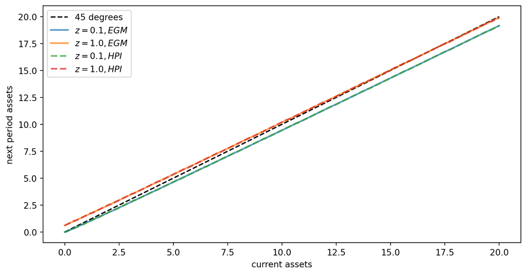

```python
sigma_a_hpi = hh.a_grid[sigma_hpi]
fig, ax = plt.subplots()
ax.plot(hh.a_grid, hh.a_grid, "k--", label="45 degrees")

for j, z in enumerate(hh.z_grid):
    lb = f"$z = {z:.2}, EGM$"
    ax.plot(hh.a_grid, sigma_a_egm[:, j], lw=2, alpha=0.7, label=lb)

for j, z in enumerate(hh.z_grid):
    lb = f"$z = {z:.2}, HPI$"
    ax.plot(hh.a_grid, sigma_a_hpi[:, j], "--", lw=2, alpha=0.7, label=lb)

ax.set_xlabel("current assets")
ax.set_ylabel("next period assets")
ax.legend(loc="upper left")
plt.show()
```

So in this Aiyagari household problem:

- VFI and HPI solve for the value function first, and then recover the policy.
- EGM solves directly for the policy using the Euler equation.
- EGM is especially attractive here because the choice variable is one-dimensional and CRRA utility makes the Euler equation easy to invert.

For the equilibrium section below, we keep using HPI because the distribution code is currently written for an **index-valued** policy $\sigma(a, z) \in \{0,1,\ldots,|A|-1\}$. To use EGM all the way through, we would need to modify the law of motion so that probability mass is split across neighboring grid points after interpolation.

## Equilibrium

We need to know how much capital households supply at a given interest rate $r$.

After we have the policy $\sigma$, we now know the transition matrix $P_\sigma$ where

$$P_\sigma(i,j) = \Pr \{a_{t+1} = a_j, z_{t+1} = z_j | a_t = a_i, z_t = z_i\}$$

In quantecon’s tutorial [here](https://jax.quantecon.org/aiyagari_jax.html), they use this following code:

```python
@jax.jit
def compute_asset_stationary(σ, household):
    # Unpack
    β, a_grid, z_grid, Π = household
    a_size, z_size = len(a_grid), len(z_grid)

    # Construct P_σ as an array of the form P_σ[i, j, ip, jp]
    ap_idx = jnp.arange(a_size)
    ap_idx = jnp.reshape(ap_idx, (1, 1, a_size, 1))
    σ = jnp.reshape(σ, (a_size, z_size, 1, 1))
    A = jnp.where(σ == ap_idx, 1, 0)
    Π = jnp.reshape(Π, (1, z_size, 1, z_size))
    P_σ = A * Π

    # Reshape P_σ into a matrix
    n = a_size * z_size
    P_σ = jnp.reshape(P_σ, (n, n))

    # Get stationary distribution and reshape back onto [i, j] grid
    ψ = compute_stationary(P_σ)
    ψ = jnp.reshape(ψ, (a_size, z_size))

    # Sum along the rows to get the marginal distribution of assets
    ψ_a = jnp.sum(ψ, axis=1)
    return ψ_a
```

## Power Iteration

But let’s do a slightly different version.

That is, we’ll do the power iteration to get the stationary distribution instead of solving the transition matrix first, this is memeory-friendly cuz if we have a large number of states, the transition matrix will be too large to store in memory.

```python
@jax.jit
def push_forward(psi, sigma, hh):
    I, J = hh.a_grid.size, hh.z_grid.size
    psi_next = jnp.zeros_like(psi)

    def body_fun(k, psi_next):
        i, j = jnp.unravel_index(k, (I, J))
        ip = sigma[i, j]
        psi_next = psi_next.at[ip, :].add(psi[i, j] * hh.Pi[j, :])
        return psi_next

    psi_next = jax.lax.fori_loop(0, I * J, body_fun, psi_next)
    return psi_next
```

## Stationary Distribution

Now we can get the stationary distribution by iterating the `push_forward` function until it converges.

```python
@jax.jit
def get_stat_asset(sigma, hh, tol=1e-12, max_iter=10_000):
    I, J = hh.a_grid.size, hh.z_grid.size
    # we make it a uniform distribution initially
    psi = jnp.ones((I, J)) / (I * J)

    def body_fun(k_psi_err):
        k, psi, err = k_psi_err
        psi_next = push_forward(psi, sigma, hh)
        err = jnp.max(jnp.abs(psi_next - psi))
        return k + 1, psi_next, err

    def cond_fun(k_psi_err):
        k, psi, err = k_psi_err
        return jnp.logical_and(k < max_iter, err > tol)

    init_val = (0, psi, jnp.inf)
    k, psi, err = jax.lax.while_loop(cond_fun, body_fun, init_val)
    return psi
```

Now it’s time to test the power iteration method.

```python
psi_iter = get_stat_asset(sigma_hpi, hh)
psi_iter_asset = jnp.sum(psi_iter, axis=1)
psi_solve_asset = compute_asset_stationary(sigma_hpi, hh)
print(jnp.allclose(psi_iter_asset, psi_solve_asset))
print(jnp.max(jnp.abs(psi_iter_asset - psi_solve_asset)))
```

```
True
2.5466139613739003e-11
```

Let’s check the distribution now:

```python
fig, ax = plt.subplots()
ax.bar(hh.a_grid, psi_iter_asset)
ax.set_xlabel("asset level")
ax.set_ylabel("probability mass")
plt.show()
```

Check if it sums to one:

```python
print(jnp.sum(psi_iter_asset))
```

```
1.0000000000000147
```

[figure not shown]

Now we can get the aggregate capital supply by households.

```python
@jax.jit
def capital_supply(sigma, hh):
    psi_asset = get_stat_asset(sigma, hh).sum(axis=1)
    return jnp.sum(psi_asset * hh.a_grid)
```

Let’s test the capital supply function:

```python
print(capital_supply(sigma_hpi, hh))
```

```
5.417634374417349
```

Alright, then remeber what we have in `r_given_k` and `w_given_r`, we can now write the equilibrium condition.

Let’s consider the mapping $K_{n+1} = G(K_n)$, where $G(K)$ is the capital supply function.

That is

```python
@jax.jit
def G(K, firm, hh):
    r = r_given_k(K, firm)
    w = w_given_r(r, firm)
    prices = create_prices(r=r, w=w)
    _, sigma = HPI_loop(hh, prices)
    return capital_supply(sigma, hh)
```

Let’s test the `G` function:

```python
k_vals = jnp.linspace(4, 12, 20)
firm = create_firm()
hh = create_HH()

G_vals = [G(k, firm, hh) for k in k_vals]
G_vals[-1].block_until_ready()
```

```
Array(8.65889621, dtype=float64)
```

Let’s plot the `G` function:

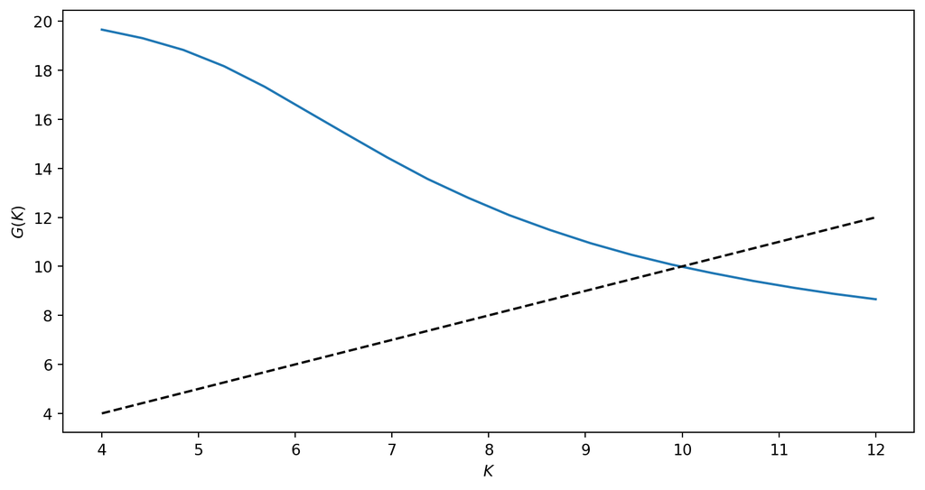

```python
fig, ax = plt.subplots()
ax.plot(k_vals, G_vals)
ax.plot(k_vals, k_vals, "k--", label="45 degrees")
ax.set_xlabel("$K$")
ax.set_ylabel("$G(K)$")
plt.show()
```

So a natural idea is to use the damped iteration scheme
$$K_{n+1} = \alpha K_n + (1-\alpha) G(K_n)$$
where $\alpha$ is a damping factor.

```python
@jax.jit
def equilibrium_damped(K0, firm, hh, alpha=0.6, max_iter=100, tol=1e-8):
    def body_fun(k_K_err):
        k, K, err = k_K_err
        K_next = alpha * K + (1 - alpha) * G(K, firm, hh)
        err = jnp.abs(K_next - K)
        return k + 1, K_next, err

    def cond_fun(k_K_err):
        k, K, err = k_K_err
        return jnp.logical_and(k < max_iter, err > tol)

    init_val = (0, K0, jnp.inf)
    k, K, err = jax.lax.while_loop(cond_fun, body_fun, init_val)
    return K
```

Let’s test the `equilibrium_damped` function:

```python
K0 = 6
firm = create_firm()
hh = create_HH()
K_star = equilibrium_damped(K0, firm, hh)
print(f"Equilibrium capital stock: {K_star}")

start_time = time.time()
K_star = equilibrium_damped(K0, firm, hh).block_until_ready()
end_time = time.time()
damped_time = end_time - start_time
print(f"Time used: {damped_time} seconds")
```

```
Equilibrium capital stock: 9.988106877194669
Time used: 0.2039480209350586 seconds
```

Let’s plot to check the result!

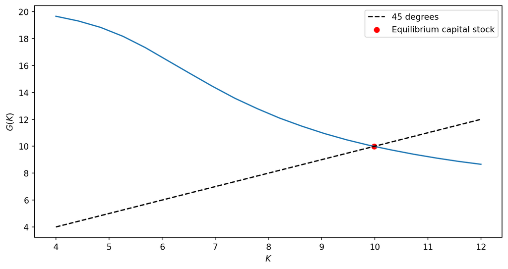

```python
fig, ax = plt.subplots()
ax.plot(k_vals, G_vals)
ax.plot(k_vals, k_vals, "k--", label="45 degrees")
ax.scatter(K_star, G(K_star, firm, hh), color="red", label="Equilibrium capital stock")
ax.set_xlabel("$K$")
ax.set_ylabel("$G(K)$")
ax.legend()
plt.show()
```